# PML project: Activity Classification

Sunday, July 26, 2015

#### Background

Using devices such as Jawbone Up, Nike FuelBand, and Fitbit it is now possible to collect a large amount of data about personal activity relatively inexpensively. These type of devices are part of the quantified self movement - a group of enthusiasts who take measurements about themselves regularly to improve their health, to find patterns in their behavior, or because they are tech geeks. One thing that people regularly do is quantify how much of a particular activity they do, but they rarely quantify how well they do it.

The objective of this project is to use data from accelerometers on the belt, forearm, arm, and dumbell of 6 participants. and predict the manner in which they did the exercise.

### Load packages and set path

```r
library(randomForest)
library(rattle)
library(caret)
library(dplyr)
setwd('F:/Statistics/Coursera/Practical machine learning/project/')
```

### Load data

Download the training and testing data through following linkes and read them into R. https://d396qusza40orc.cloudfront.net/predmachlearn/pml-training.csv https://d396qusza40orc.cloudfront.net/predmachlearn/pml-testing.csv

Note here both ‘NA’ and ’’ are treated as missing while reading into R.

```r
train = read.csv('pml-training.csv', na.strings = c("NA", ""))
test = read.csv('pml-testing.csv', na.strings = c("NA", ""))
```

### Data processing

Data processing takes three steps on the training set. At first, I separate trainging set into training and testing set by 60% and 40%. Then I expored and remove variables with a great amount of missing data. In the last step, I remove the first five varibales which don’t provide much information for classification.

```r
set.seed(12345)
train.indx = createDataPartition(train$classe, p=0.6, list=FALSE)
my.train = train[train.indx,]
my.test = train[-train.indx,]

na.list = sapply(my.train, function(x) {sum(is.na(x))})
table(na.list)
```

```
## na.list
##     0 11543
##    60   100
```

```r
drop.name = names(na.list[na.list == 11543])
my.train.1 = my.train[, !(names(train) %in% drop.name)]

near.zero = nearZeroVar(my.train.1, saveMetrics=TRUE)
drop.name = rownames(near.zero[near.zero$nzv == TRUE,])
my.train.2 = my.train.1[, !(names(my.train.1) %in% drop.name)]

my.train.final = my.train.2[,-c(1,2,3,4,5)]
str(my.train.final)
```

```
## 'data.frame':    11776 obs. of  54 variables:
##  $ num_window          : int  11 11 12 12 12 12 12 12 12 12 ...
##  $ roll_belt           : num  1.41 1.42 1.48 1.42 1.42 1.43 1.42 1.51 1.59 1.57 ...
##  $ pitch_belt          : num  8.07 8.07 8.05 8.09 8.13 8.18 8.21 8.12 8.07 8.09 ...
##  $ yaw_belt            : num  -94.4 -94.4 -94.4 -94.4 -94.4 -94.4 -94.4 -94.4 -94.4 -94.4 ...
##  $ total_accel_belt    : int  3 3 3 3 3 3 3 3 3 3 ...
##  $ gyros_belt_x        : num  0.02 0 0.02 0.02 0.02 0.02 0.02 0 0.02 0.02 ...
##  $ gyros_belt_y        : num  0 0 0 0 0 0 0 0 0 0.02 ...
##  $ gyros_belt_z        : num  -0.02 -0.02 -0.03 -0.02 -0.02 -0.02 -0.02 -0.02 -0.02 -0.02 ...
##  $ accel_belt_x        : int  -22 -20 -22 -22 -22 -22 -22 -21 -22 -21 ...
##  $ accel_belt_y        : int  4 5 3 3 4 2 4 4 5 3 ...
##  $ accel_belt_z        : int  22 23 21 21 21 23 21 22 22 21 ...
##  $ magnet_belt_x       : int  -7 -2 -6 -4 -2 -2 -8 -6 -1 -2 ...
##  $ magnet_belt_y       : int  608 600 604 599 603 602 598 598 604 604 ...
##  $ magnet_belt_z       : int  -311 -305 -310 -311 -313 -319 -310 -317 -314 -313 ...
```

[output cut: 40 more lines]

### Results

#### Algorithm 1: Decision Tree

```r
tree.fit = train(classe ~., method='rpart', data = my.train.final)
print(tree.fit$finalModel)
```

```
## n= 11776
##
## node), split, n, loss, yval, (yprob)
##       * denotes terminal node
##
##  1) root 11776 8428 A (0.28 0.19 0.17 0.16 0.18)
##    2) roll_belt< 130.5 10799 7457 A (0.31 0.21 0.19 0.18 0.11)
##      4) pitch_forearm< -33.95 945    8 A (0.99 0.0085 0 0 0) *
##      5) pitch_forearm>=-33.95 9854 7449 A (0.24 0.23 0.21 0.2 0.12)
##       10) num_window>=45.5 9414 7009 A (0.26 0.24 0.22 0.2 0.089)
##         20) num_window< 241.5 2136  999 A (0.53 0.12 0.1 0.19 0.05) *
##         21) num_window>=241.5 7278 5265 B (0.17 0.28 0.25 0.2 0.1)
##           42) magnet_dumbbell_z< -28.5 1903  995 A (0.48 0.35 0.04 0.12 0.011) *
##           43) magnet_dumbbell_z>=-28.5 5375 3621 C (0.067 0.25 0.33 0.23 0.13) *
##       11) num_window< 45.5 440   83 E (0 0 0 0.19 0.81) *
##    3) roll_belt>=130.5 977    6 E (0.0061 0 0 0 0.99) *
```

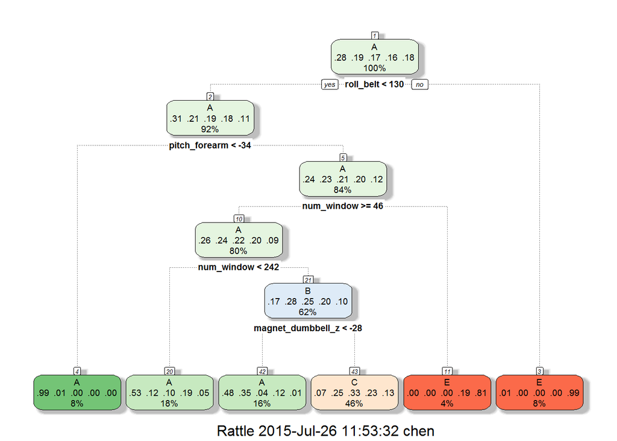

```r
fancyRpartPlot(tree.fit$finalModel)
```

```r
pred = predict(tree.fit, newdata = my.test)
print(confusionMatrix(pred, my.test$classe))
```

```
## Confusion Matrix and Statistics
##
##           Reference
## Prediction    A    B    C    D    E
##          A 2008  635  219  420   95
##          B    0    0    0    0    0
##          C  216  883 1149  803  471
##          D    0    0    0    0    0
##          E    8    0    0   63  876
##
## Overall Statistics
##
##                Accuracy : 0.514
##                  95% CI : (0.5029, 0.5251)
##     No Information Rate : 0.2845
##     P-Value [Acc > NIR] : < 2.2e-16
##
##                   Kappa : 0.3746
##  Mcnemar's Test P-Value : NA
##
## Statistics by Class:
##
##                      Class: A Class: B Class: C Class: D Class: E
## Sensitivity            0.8996   0.0000   0.8399   0.0000   0.6075
## Specificity            0.7561   1.0000   0.6337   1.0000   0.9889
## Pos Pred Value         0.5946      NaN   0.3262      NaN   0.9250
## Neg Pred Value         0.9499   0.8065   0.9494   0.8361   0.9180
## Prevalence             0.2845   0.1935   0.1744   0.1639   0.1838
## Detection Rate         0.2559   0.0000   0.1464   0.0000   0.1116
## Detection Prevalence   0.4304   0.0000   0.4489   0.0000   0.1207
## Balanced Accuracy      0.8279   0.5000   0.7368   0.5000   0.7982
```

#### Algorithm 2: Random forrest

Accuracy of tree model is not very satisfying. In order to improve it, I tried random forrest algorithm. Out of sample error has been greatly reduced to 0.3%.

```r
rf.fit <- train(classe ~., method="rf", data=my.train.final)
print(rf.fit, digits=3)
```

```
## Random Forest
##
## 11776 samples
##    53 predictor
##     5 classes: 'A', 'B', 'C', 'D', 'E'
##
## No pre-processing
## Resampling: Bootstrapped (25 reps)
##
## Summary of sample sizes: 11776, 11776, 11776, 11776, 11776, 11776, ...
##
## Resampling results across tuning parameters:
##
##   mtry  Accuracy  Kappa  Accuracy SD  Kappa SD
##    2    0.989     0.987  0.00197      0.00249
##   27    0.994     0.993  0.00149      0.00189
##   53    0.991     0.989  0.00217      0.00275
##
## Accuracy was used to select the optimal model using  the largest value.
## The final value used for the model was mtry = 27.
```

```r
pred = predict(rf.fit, newdata = my.test)
print(confusionMatrix(pred, my.test$classe))
```

```
## Confusion Matrix and Statistics
##
##           Reference
## Prediction    A    B    C    D    E
##          A 2232    2    0    0    0
##          B    0 1511    2    0    2
##          C    0    5 1366   10    0
##          D    0    0    0 1276    2
##          E    0    0    0    0 1438
##
## Overall Statistics
##
##                Accuracy : 0.9971
##                  95% CI : (0.9956, 0.9981)
##     No Information Rate : 0.2845
##     P-Value [Acc > NIR] : < 2.2e-16
##
##                   Kappa : 0.9963
##  Mcnemar's Test P-Value : NA
##
## Statistics by Class:
##
##                      Class: A Class: B Class: C Class: D Class: E
## Sensitivity            1.0000   0.9954   0.9985   0.9922   0.9972
## Specificity            0.9996   0.9994   0.9977   0.9997   1.0000
## Pos Pred Value         0.9991   0.9974   0.9891   0.9984   1.0000
## Neg Pred Value         1.0000   0.9989   0.9997   0.9985   0.9994
## Prevalence             0.2845   0.1935   0.1744   0.1639   0.1838
## Detection Rate         0.2845   0.1926   0.1741   0.1626   0.1833
## Detection Prevalence   0.2847   0.1931   0.1760   0.1629   0.1833
## Balanced Accuracy      0.9998   0.9974   0.9981   0.9960   0.9986
```

#### Final choice

Bacuse of much better prediction precision, I decide to use random forrest as the final algorithm for this activity data.

#### Submit answers

```r
pred = predict(rf.fit, newdata = test)
pml_write_files = function(x){
    n = length(x)
    for(i in 1:n){
        filename = paste0("problem_id_",i,".txt")
        write.table(x[i], file=filename, quote=FALSE, row.names=FALSE, col.names=FALSE)
    }
}
pml_write_files(pred)
```